# 6주차 발표

이석희

2019. 09. 10.

## *3.7_* **사전 작업**

##### *Blood Type Table*

```r
gender <- c("남", "여", "남", "여", "남",
            "여", "남", "여", "남", "여",
            "남", "여", "남", "여", "남",
            "여", "남", "여", "남", "여")
bloodType <- c('A', 'B', 'A', 'AB',
               'O', 'A', 'O', 'B',
               'A', 'O', 'O', 'B',
               'O', 'A', 'AB', 'B',
               'O', 'A', 'A', 'B')
classDF <- data.frame(gender, bloodType)
classTable <-  table(classDF)
classTable
```

```
      bloodType
gender A AB B O
    남 4  1 0 5
    여 3  1 5 1
```

# *3.8_강력한 시각화 패키지 ggplot2*

## *3.8.1* **패키지 설치 및 로드**

##### *1.* **패키지 설치**

```r
# ggplot2 패키지 설치
# install.packages("ggplot2")
```

##### *2.* **메모리에 패키지 로드**

```r
# ggplot2 로드
library("ggplot2")
```

## *3.8.2* **그래프 그릴 공간 만들기**

그래프를 그리려면 그래프를 초기화하고 사용할 데이터를 지정하는 ggplot 함수를 정의해야 합니다.

#### *ggplot(data, aes(x, y, .. ))*

**- data**

그래프에 사용할 데이터프레임

**- aes(x, y, .. )**

aes는 에스테틱(aesthetic, 미적인)을 뜻합니다. 데이터의 항목과 시각적 요소를 연결하는 정보(Aesthetic mappings). 그래프 전체에 적용할 연결 정보는 ggplot 함수 내에 설정합니다.

##### *Example*

아래는 ggplot 함수를 활용해 그래프 공간 생성하는 예시입니다. ggplot 함수는 테이블 타입의 데이터는 사용할 수 없으므로 데이터프레임으로 변환 후 입력해야 합니다. 그리고 aes를 활용해 x축에는 혈액형(bloodType)을, y축에는 빈도수(Feq)를 연결합니다.

```r
# ggplot2 패키지 로드
library(ggplot2)

# 혈액형/성별 간 빈도수가 표현된 테이블 객체
classTable
```

```
      bloodType
gender A AB B O
    남 4  1 0 5
    여 3  1 5 1
```

```r
# 데이터 프레임 변환(conversion of dataframe)과 그 결과
classCovDF <- as.data.frame(classTable)
classCovDF
```

```
  gender bloodType Freq
1     남         A    4
2     여         A    3
3     남        AB    1
4     여        AB    1
5     남         B    0
6     여         B    5
7     남         O    5
8     여         O    1
```

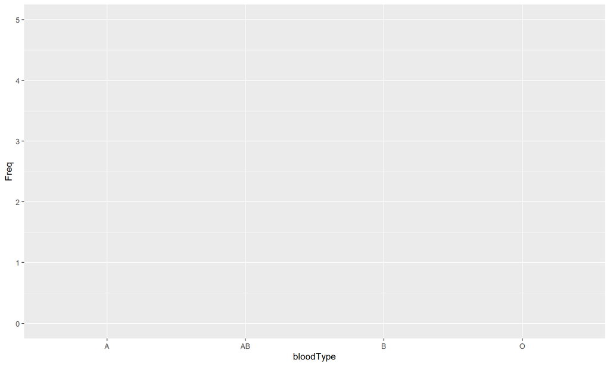

```r
# ggplot 함수 실행. aes를 통해 x/y축에 매핑할 데이터 항목을 지정
# ggplot 함수를 실행하면 x축에는 혈액형(bloodType), y축에는 빈도수(Freq) 항목이 연결된 공간이 만들어집니다.
ggplot(classCovDF, aes(x = bloodType, y = Freq))
```

## *3.8.3* **표현할 그래프 종류 선택하기**

ggplot으로 만들어진 공간에 그래프를 그리려면 geoms 계열 함수(geom으로 시작하는 그래프 종류 함수)를 연결시켜야 합니다. 교재 193쪽에는 차트 예시가 몇 가지 제시되는데요, 우리는 “+” 기호를 통해 geom_col 함수를 추가해보겠습니다.

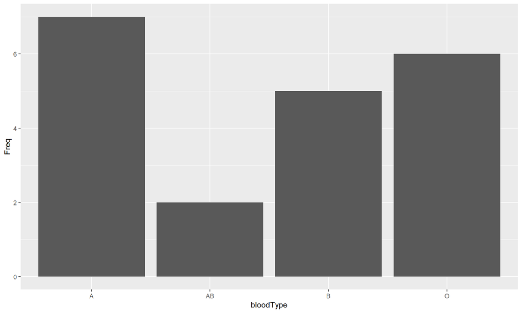

```r
# 막대 차트 만들기
ggplot(classCovDF,
       aes(x = bloodType, y = Freq)) + geom_col()
```

이번에는 생성된 막대차트 안에 성별을 색상으로 구분하기 위해 aes 항목에 그래프의 색상 채우기(fill)와 성별(gender)을 추가로 연결해보겠습니다. 시각적 요소와 데이터 항목을 연결하는 aes 정보를 그래프 전체에 적용하고 싶다면 ggplot 함수 안에 저장하고, geoms 계열 함수 안에 국한해서 적용하고 싶다면 geoms 함수에 지정합니다. 본 예제에서는 geom_col 함수 하나만 적용하기 때문에 어디에 지정하든 결과는 같지만 막대차트 내에 성별을 색상으로 표현하기 때문에 geom_col 함수에 aes 항목을 지정해보겠습니다.

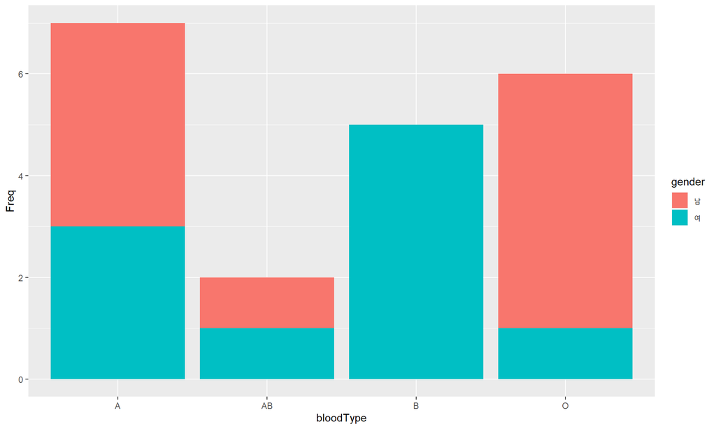

```r
# aes에 색상 채우기(fill)와 성별 항목 연결 추가
ggplot(classCovDF,
       aes(x = bloodType, y = Freq)) + geom_col(aes(fill = gender))
```

이처럼 ggplot2는 특별한 설정 없이도 보고서 등에 바로 사용 가능한 수준의 디자인을 제공함으로써 사용자에게 디자인에 대한 부담을 덜어 줍니다.

## *3.8.4* **부가 정보 추가하기**

ggtitle 함수를 연결해 제목을 추가해 보겠습니다.

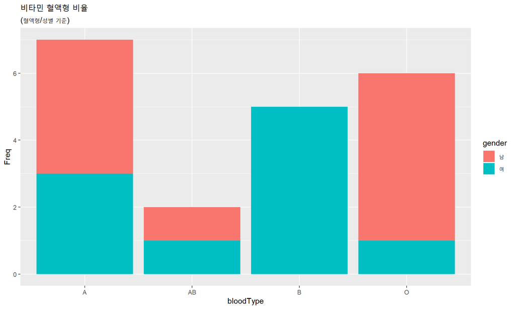

```r
# ggplot의 제목 추가하기
ggplot(classCovDF,
       aes(x = bloodType, y = Freq)) +
geom_col(aes(fill = gender)) +
ggtitle("비타민 혈액형 비율", subtitle = "(혈액형/성별 기준)")
```

labs 함수를 추가해 x축과 y축, 범례 제목도 변경하겠습니다.

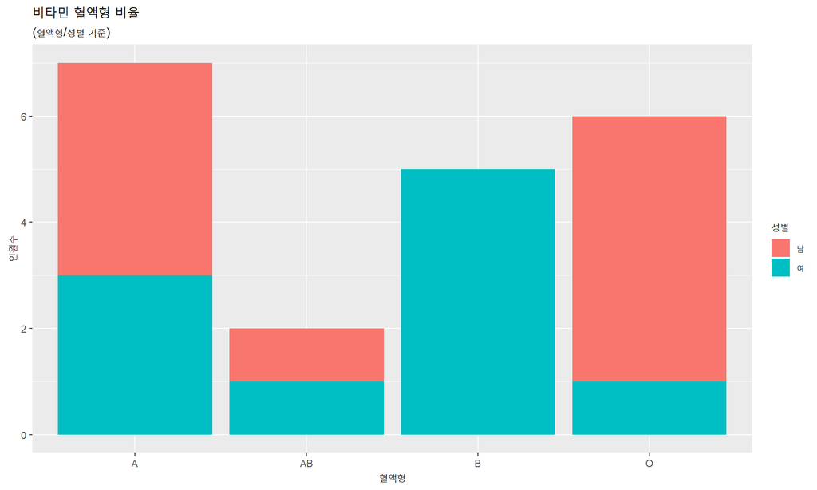

```r
# ggplot의 x/y축 및 범례 제목 변경
ggplot(classCovDF,
       aes(x = bloodType, y = Freq)) +
geom_col(aes(fill = gender)) +
ggtitle("비타민 혈액형 비율", subtitle = "(혈액형/성별 기준)") +
labs(x = "혈액형",
     y = "인원수",
     fill = "성별")
```

## *3.8.5* **테마 지정하기**

테마(theme) 함수를 추가해 그래프의 분위기를 바꿀 수도 있습니다.

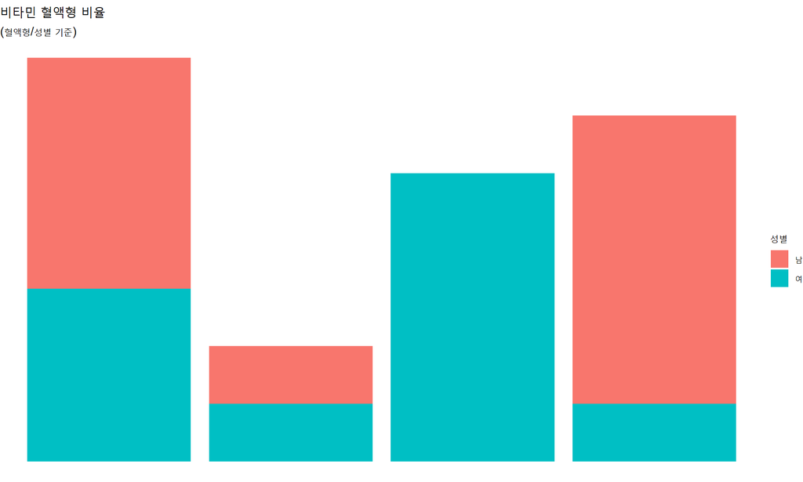

```r
# 그래프 객체 생성
BloodbarChart <- ggplot(classCovDF,
                       aes(x = bloodType, y = Freq)) +
                geom_col(aes(fill = gender)) +
                ggtitle("비타민 혈액형 비율",
                        subtitle = "(혈액형/성별 기준)") +
                labs(x = "혈액형",
                     y = "인원수",
                     fill = "성별")
# theme_void 적용
BloodbarChart + theme_void()
```

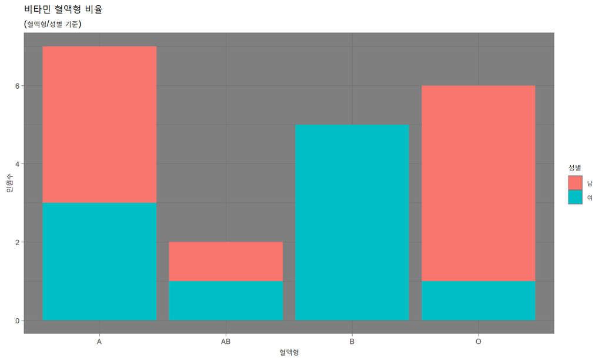

```r
# theme_dark 적용
BloodbarChart + theme_dark()
```

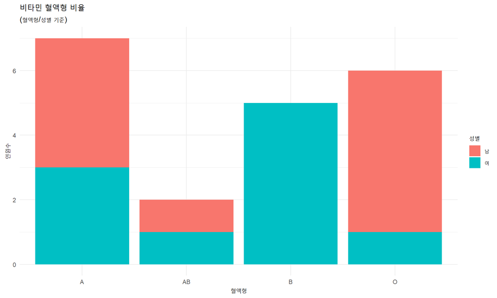

```r
# theme_minimal 적용
BloodbarChart + theme_minimal()
```

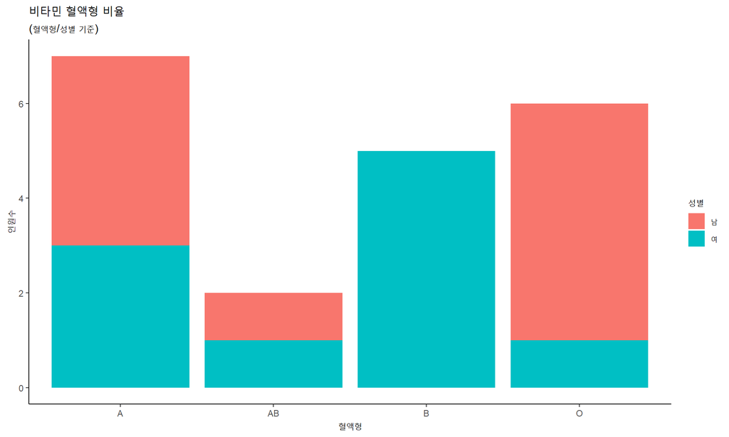

```r
# theme_classic 적용
BloodbarChart + theme_classic()
```

## *3.8* **마무리**

ggplot은 “+” 기호를 이용해 세밀한 시각화 작업이 가능합니다. 그러나 R 기본 그래픽 함수는 코드가 짧고 별도의 설치 없이 바로 사용할 수 있으므로 유용합니다.

##### *+Alpha 1:* geom_point, geom_line 함수

geoms 계열 함수를 “+”로 연결해 여러 종류의 그래프를 겹쳐 표현할 수 있습니다. 기존에 생성된 막대 차트에 geom_point 함수를 연결해 혈액형별 빈도수를 점으로 표현하고, 성별은 점의 모양으로 구분지어 표현해 보겠습니다.

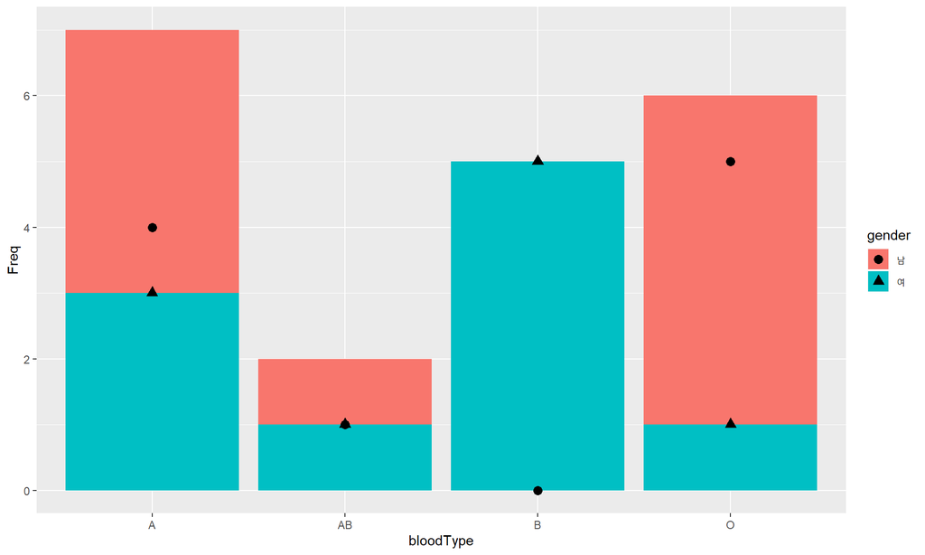

```r
# geom_point 추가. 점의 모양과 성별을 연결한 aes 정보 추가. 점의 크기는 3
ggplot(classCovDF,
       aes(x = bloodType, y = Freq)) +
geom_col(aes(fill = gender)) +
geom_point(aes(shape = gender), size = 3)
```

이번에는 geom_line 함수를 추가해 성별을 기준으로 빈도수를 선으로 연결(group)하고 선 모양도 성별 간 구분(linetype)되게 표현해 보겠습니다.

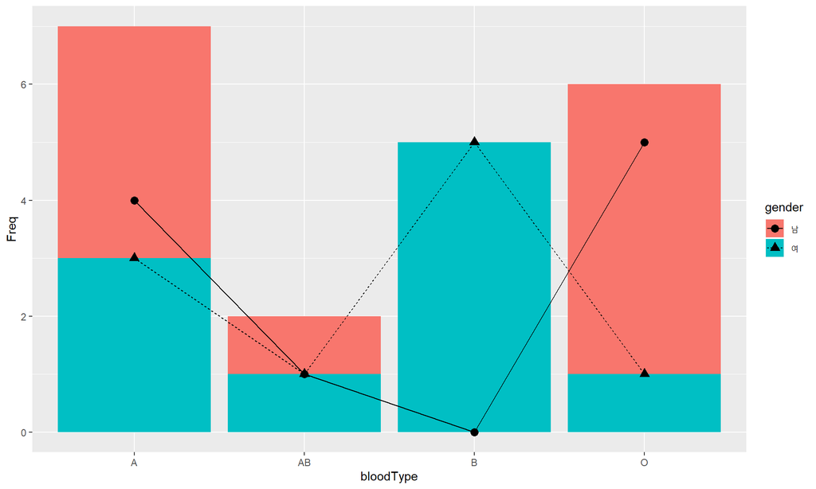

```r
# geom_line 추가. 선 연결 기준(group)과 선 모양(linetype)을 성별과 연결한 aes 정보 추가
ggplot(classCovDF,
       aes(x = bloodType, y = Freq)) +
geom_col(aes(fill = gender)) +
geom_point(aes(shape = gender), size = 3) +
geom_line(aes(group = gender, linetype = gender))
```

##### *+Alpha 2:* 그래프 꾸미기

ggtitle 함수에서 글씨체, 글씨 모양, 가운데 정렬, 크기, 색상을 설정할 수 있습니다. 이와 관련해 아래를 참고하시길 바랍니다.

링크1 [링크2](http://nife0719.blog.me/221000580841) [링크3](http://ggplot2.tidyverse.org/reference/)

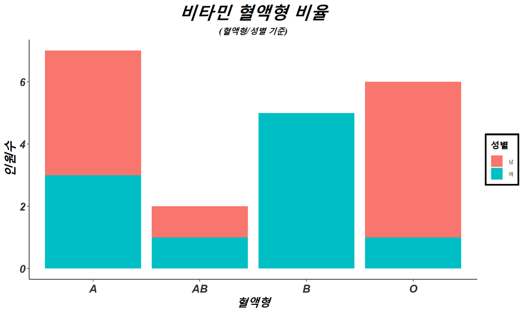

```r
# ggplot 그래프 꾸미기
BloodbarChart +
theme_classic() +
theme(plot.title = element_text(family = "serif",
                                face = "bold.italic",
                                hjust = 0.5,
                                size = 30,
                                color = "black"),
      plot.subtitle  = element_text(family = "serif",
                                face = "bold.italic",
                                hjust = 0.5,
                                size = 13,
                                color = "black"),
      axis.title = element_text(face = "bold.italic", size = 20, color = "black"),
      axis.text.x = element_text(colour="grey20", size=15, hjust=.5, vjust=.5, face = "bold.italic"),
      axis.text.y = element_text(colour="grey20", size=15, face = "bold.italic")) +
theme(legend.title = element_text(face = "bold", size = 15, color = "Black")) +
theme(legend.box.background = element_rect(fill = "Black"), legend.box.margin = margin(2, 2, 2, 2))
```

##### *+Alpha 3:* 명령어가 여러 행으로 구성될 때 연결 기호 “+”의 위치

ggplot2 패키지로 그래프를 만들 때 명령어가 길어지면 여러 행으로 작성하게 되는데 이때 함수들을 연결하는 “+”는 이전 함수와 동일한 행에 위치해야 합니다. 만약 행이 시작하는 위치에 “+” 기호를 입력하면 다른 명령어로 인식해 오류가 발생합니다.

아래와 같이 이전 함수 뒤에 “+”를 입력하면 정상 출력됩니다.

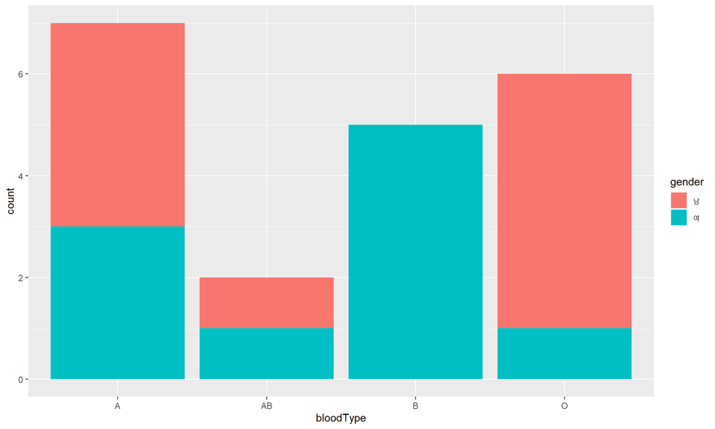

```r
#"+" 기호를 행이 시작하는 위치에 입력: 다른 명령어로 인식해 오류가 발생
# ggplot(classDF, aes(x = bloodType, fill = gender))
# + geom_bar()

# + 기호는 이전 함수 뒤에 표현: 정상 처리됨
ggplot(classDF,
       aes(x = bloodType, fill = gender)) +
geom_bar()
```

##### *+Alpha 4:* ggplot2 패키지의 막대차트 함수: geom_bar와 geom_col

- **시각화하려는 데이터에 막대의 높이 정보가 있다면:** geom_col 함수를 사용
- **항목의 건수 등을 직접 계산해서 높이를 산출해야 한다면:** geo_bar 함수를 사용

```r
# 혈액형별 빈도수가 이미 계산된 경우
library(plyr)
col_data <- data.frame(count(bloodType))
names(col_data) <- c("bloodType", "Freq")
col_data
```

```
  bloodType Freq
1         A    7
2        AB    2
3         B    5
4         O    6
```

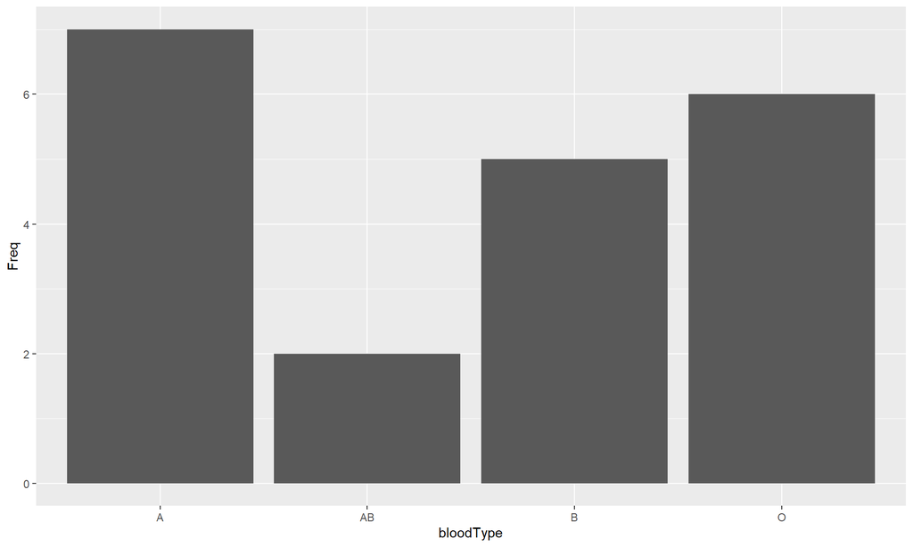

```r
# x축에 혈액형, y축에 이미 계산된 빈도수를 연결해서 geom_col 함수로 막대차트를 생성
ggplot(col_data, aes(x = bloodType, y = Freq)) +
geom_col()
```

```r
# 혈액형 정보가 나열되어 있음
bar_data <- data.frame(bloodType)
bar_data
```

```
   bloodType
1          A
2          B
3          A
4         AB
5          O
6          A
7          O
8          B
9          A
10         O
11         O
12         B
13         O
14         A
15        AB
16         B
17         O
18         A
19         A
20         B
```

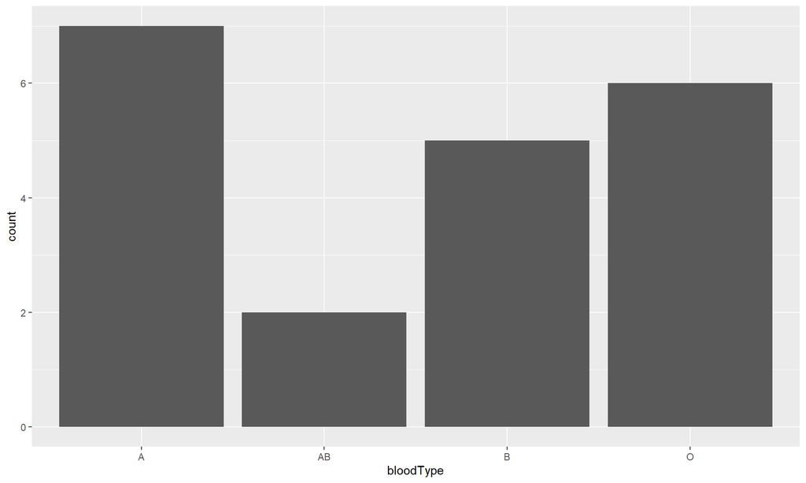

```r
# x축에 혈액형을 연결하면 y축은 자동으로 빈도수를 계산해 표현
ggplot(bar_data, aes(x = bloodType)) +
geom_bar()
```

##### *+Alpha 4:* geom_bar 심화

[geom_bar 설명 링크](https://www.rdocumentation.org/packages/ggplot2/versions/1.0.1/topics/geom_bar)

#### *geom_bar(stat = “bin”, position = “stack”, …)*

**- stat**

stat은 “The statistical transformation to use on the data for this layer”을 뜻합니다. 각 데이터에 따른 통계치를 어떻게 변형해 사용할 것인지 정할 수 있습니다.

**- position**

position은 쌓아올릴 통계치의 위치를 지정합니다. 한곳에 누적해서 쌓아올릴 수도, 따로따로 쌓아올릴 수도 있습니다.

- **남녀 통계치를 누적해서 하나의 막대로 보고 싶다면:** position = “stack”
- **남녀 통계치를 따로 보고 싶다면:** position = “dodge”

**dodge:** 재빨리 몸을 움직이다, 기피하다. 럭비에서 상대편의 태클이나 수비를 교묘한 동작과 발놀림으로 피하여 빠져나가는 기술.

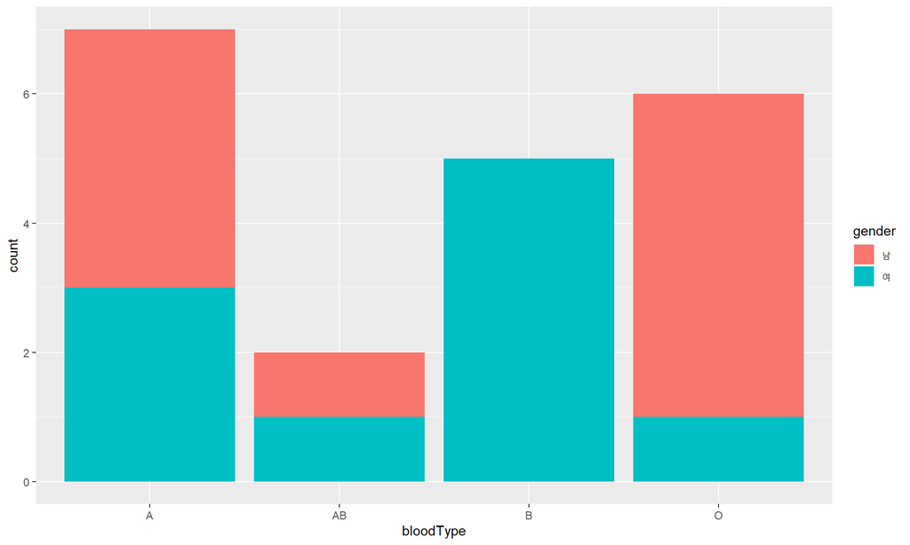

```r
# ggplot에서 aes(fill = gender) 설정
ggplot(bar_data, aes(bloodType, fill = gender)) +
geom_bar() # default: position = "stack"
```

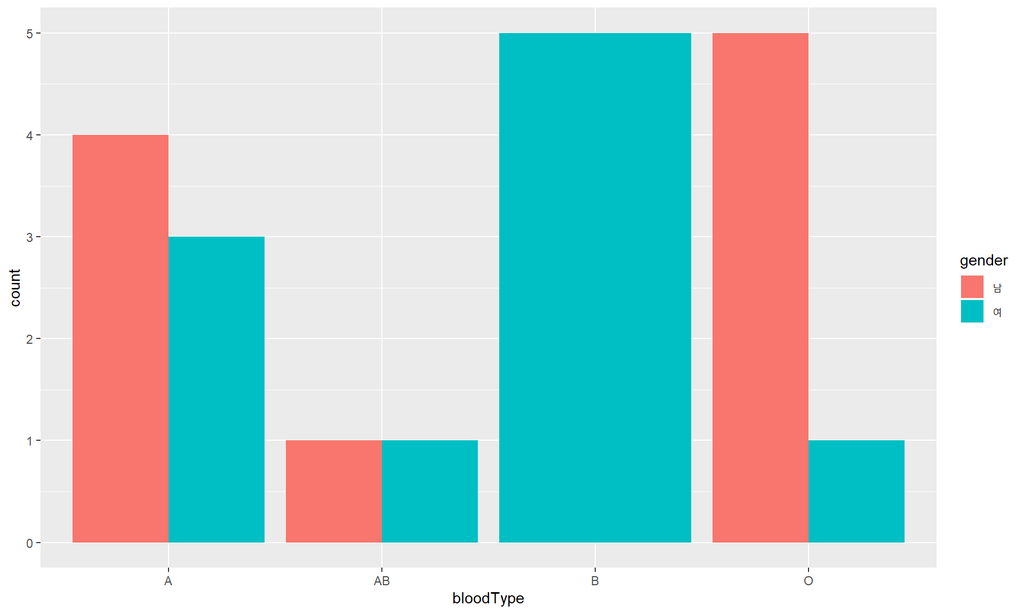

```r
ggplot(bar_data, aes(bloodType, fill = gender)) +
geom_bar(position = "dodge")
```

- **오로지 각 카테고리의 빈도 수만 보고 싶다면:** stat = “bin”
- **각 카테고리에 해당하는 값을 구분해 y축으로 계산:** stat = “identity”

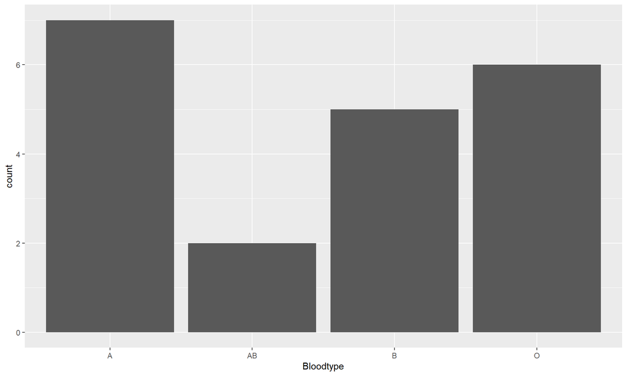

```r
Bloodtype <- c('A', 'B', 'A', 'AB',
               'O', 'A', 'O', 'B',
               'A', 'O', 'O', 'B',
               'O', 'A', 'AB', 'B',
               'O', 'A', 'A', 'B')
Vision <- c(1.0, 1.2, 0.3, 0.4,
            0.5, 1.5, 0.6, 0.4,
            0.8, 0.7, 1.0, 2.0,
            1.2, 0.2, 0.1, 0.2,
            0.4, 0.5, 0.7, 0.8)
Blood_Vision <- data.frame(Bloodtype, Vision)

ggplot(Blood_Vision, aes(x = Bloodtype)) +
geom_bar() # default: stat = "bin"
```

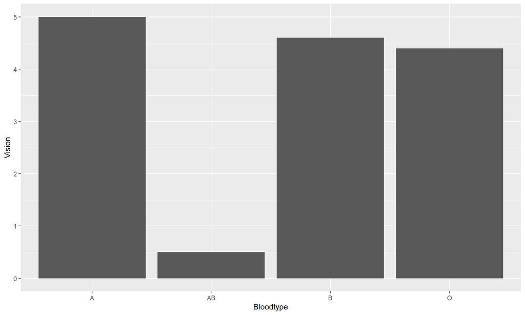

```r
ggplot(Blood_Vision, aes(x = Bloodtype, y = Vision)) +
geom_bar(stat = "identity") # 막대의 높이: 각 카테고리에 해당하는 Vision의 합
```

## *Boxplot*

ggplot에서 boxplot을 설정할 수 있습니다.

#### *geom_boxplot(outlier.~)*

**- outlier.shape**

이상치의 모양을 결정합니다. 모양을 NA로 지정하면 아예 숨길 수 있습니다(NA). 초깃값은 19입니다.  
[geom_boxplot 설명 링크_1](https://www.rdocumentation.org/packages/ggplot2/versions/3.2.1/topics/geom_boxplot)  
[geom_boxplot 설명 링크_2](https://blog.naver.com/coder1252/220987370719)

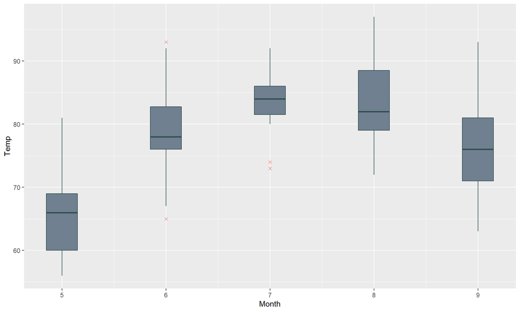

```r
data("airquality")
ggplot(data = airquality,
       aes( x =  Month, y = Temp, group = Month)) +
geom_boxplot(fill = 'slategrey', color = 'darkslategrey', width = 0.3,
             outlier.color = 'red', outlier.shape = 4)
```

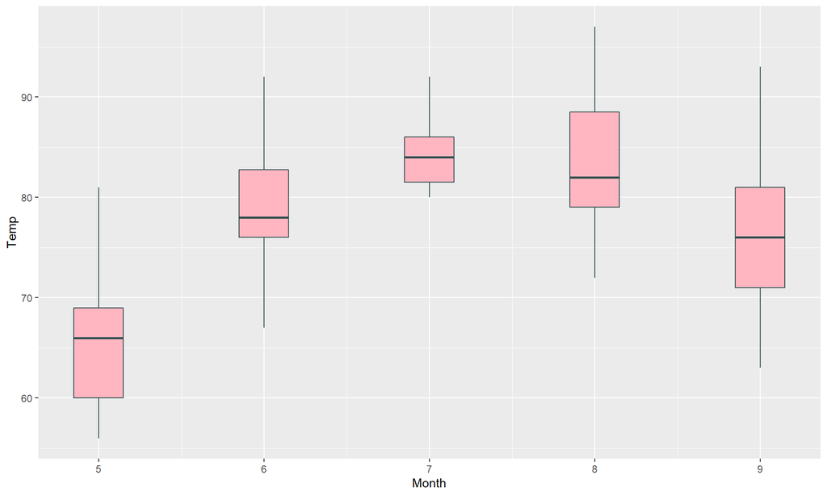

```r
ggplot(data = airquality,
       aes( x =  Month, y = Temp, group = Month)) +
geom_boxplot(fill = 'lightpink', color = 'darkslategrey', width = 0.3,
             outlier.shape = NA)
```